# 5205 final prj Q2 h3

ZiYan Cui

4/19/2023

```r
setwd("C:/Users/Roger/Desktop")
library(tidyverse)
library(tm)
library(tidytext)
library(stringr)
library(dplyr)
library(wordcloud)
library(tidyr); library(ggplot2); library(ggthemes)
library(grid)
library(gridExtra)
disneyland<- disneyland <- read_csv("disneyland.csv")
rides <- read_csv('rides.csv')
```

# Research Question 2

## Hypothesis 3:

H0: Regarding to ride experiences, reviewers visit different branches tend to give similar reviews and ratings.  
Ha: Regarding to ride experiences, reviewers visit different branches tend to give different reviews and ratings.

### Get ride names

```r
rides_name <- rides$Ride_name
rides_name
```

[output not shown]

```r
#rides_name[1:14]
disneyland_ride <- disneyland %>%
  mutate(Astro_Orbiter = case_when(grepl(c("astro orbiter", "Astro", "Orbiter"), Review_Text, ignore.case = TRUE) ~ 1,
                                   TRUE ~ 0)) %>%
  mutate(Avatar_Flight = case_when(grepl(c("Avatar Flight of Passage", "Avatar Flight", "Avatar Ride"), Review_Text, ignore.case = TRUE) ~ 1,
                                   TRUE ~ 0)) %>%
  mutate(Big_Thunder = case_when(grepl(c("Big Thunder Mountain Railroad", "Big Thunder"), Review_Text, ignore.case = TRUE) ~ 1,
                                   TRUE ~ 0)) %>%
  mutate(Buzz_Lightyear = case_when(grepl(c("Buzz Lightyear's Space Ranger Spin", "Buzz Lightyear's", "Space Ranger Spin", "Space Ranger"), Review_Text, ignore.case = TRUE) ~ 1,
                                   TRUE ~ 0)) %>%
  mutate(Dinosaur = case_when(grepl(c("Dinosaur"), Review_Text, ignore.case = TRUE) ~ 1,
                                   TRUE ~ 0)) %>%
  mutate(Dumbo = case_when(grepl(c("Dumbo the Flying Elephant", "Flying Elephant"), Review_Text, ignore.case = TRUE) ~ 1,
                                   TRUE ~ 0)) %>%
  mutate(Expedition_Everest = case_when(grepl(c("Expedition Everest"), Review_Text, ignore.case = TRUE) ~ 1,
                                   TRUE ~ 0)) %>%
  mutate(Frozen_Ever = case_when(grepl(c("Frozen Ever After", "Ever After"), Review_Text, ignore.case = TRUE) ~ 1,
                                   TRUE ~ 0)) %>%
  mutate(Gran_Fiesta = case_when(grepl(c("Gran Fiesta Tour Starring The Three Caballeros", "Gran Fiesta", "Starring The Three Caballeros", "Three Caballeros"), Review_Text, ignore.case = TRUE) ~ 1,
                                   TRUE ~ 0)) %>%
  mutate(Haunted_Mansion = case_when(grepl(c("Haunted Mansion"), Review_Text, ignore.case = TRUE) ~ 1,
                                   TRUE ~ 0)) %>%
  mutate(Small_World= case_when(grepl(c("It's a Small World", "Small World"), Review_Text, ignore.case = TRUE) ~ 1,
                                   TRUE ~ 0)) %>%
  mutate(Journey_Into= case_when(grepl(c("Journey Into Imagination with Figment", "Imagination with Figment"), Review_Text, ignore.case = TRUE) ~ 1,
                                   TRUE ~ 0)) %>%
  mutate(Jungle_Cruise= case_when(grepl(c("Jungle Cruise"), Review_Text, ignore.case = TRUE) ~ 1,
                                   TRUE ~ 0)) %>%
  mutate(Kali_River = case_when(grepl(c("Kali River Rapids", "Kali River"), Review_Text, ignore.case = TRUE) ~ 1,
                                   TRUE ~ 0))
```

```r
#rides_name[15:28]
disneyland_ride <- disneyland_ride %>%
  mutate(Kilimanjaro_Safaris = case_when(grepl(c("Kilimanjaro Safaris", "Kilimanjaro"), Review_Text, ignore.case = TRUE) ~ 1,
                                   TRUE ~ 0)) %>%
  mutate(Living_With = case_when(grepl(c("Living with the Land"), Review_Text, ignore.case = TRUE) ~ 1,
                                   TRUE ~ 0)) %>%
  mutate(Mad_Tea = case_when(grepl(c("Mad Tea Party", "Mad Tea"), Review_Text, ignore.case = TRUE) ~ 1,
                                   TRUE ~ 0)) %>%
  mutate(Mission_Space = case_when(grepl(c("Mission Space"), Review_Text, ignore.case = TRUE) ~ 1,
                                   TRUE ~ 0)) %>%
  mutate(Navi_River = case_when(grepl(c("Na'vi River Journey", "Na'vi"), Review_Text, ignore.case = TRUE) ~ 1,
                                   TRUE ~ 0)) %>%
  mutate(Peter_Pan = case_when(grepl(c("Peter Pan's Flight", "Peter Pan's"), Review_Text, ignore.case = TRUE) ~ 1,
                                   TRUE ~ 0)) %>%
  mutate(Pirates = case_when(grepl(c("Pirates of the Caribbean", "Pirates", "Caribbean"), Review_Text, ignore.case = TRUE) ~ 1,
                                   TRUE ~ 0)) %>%
  mutate(Primeval_Whirl = case_when(grepl(c("Primeval Whirl"), Review_Text, ignore.case = TRUE) ~ 1,
                                   TRUE ~ 0)) %>%
  mutate(Prince_Charming = case_when(grepl(c("Prince Charming Regal Carrousel", "Regal Carrousel"), Review_Text, ignore.case = TRUE) ~ 1,
                                   TRUE ~ 0)) %>%
  mutate(Rock_Roller = case_when(grepl(c("Rock 'n' Roller Coaster", "Rock n"), Review_Text, ignore.case = TRUE) ~ 1,
                                   TRUE ~ 0)) %>%
  mutate(Seven_Dwarfs = case_when(grepl(c("Seven Dwarfs Mine Train", "Mine Train"), Review_Text, ignore.case = TRUE) ~ 1,
                                   TRUE ~ 0)) %>%
  mutate(Soarin_Around = case_when(grepl(c("Soarin' Around the World", "Soaring Around", "Soarin' Around"), Review_Text, ignore.case = TRUE) ~ 1,
                                   TRUE ~ 0)) %>%
  mutate(Space_Mountain = case_when(grepl(c("Space Mountain"), Review_Text, ignore.case = TRUE) ~ 1,
                                   TRUE ~ 0)) %>%
  mutate(Spaceship_Earthn = case_when(grepl(c("Spaceship Earth"), Review_Text, ignore.case = TRUE) ~ 1,
                                   TRUE ~ 0))
```

```r
#rides_name[29:42]
disneyland_ride <- disneyland_ride %>%
  mutate(Splash_Mountain = case_when(grepl(c("Splash Mountain"), Review_Text, ignore.case = TRUE) ~ 1,
                                   TRUE ~ 0)) %>%
  mutate(Star_Tours = case_when(grepl(c("Star Tours"), Review_Text, ignore.case = TRUE) ~ 1,
                                   TRUE ~ 0)) %>%
  mutate(Test_Track = case_when(grepl(c("Test Track"), Review_Text, ignore.case = TRUE) ~ 1,
                                   TRUE ~ 0)) %>%
  mutate(Barnstormer = case_when(grepl(c("The Barnstormer"), Review_Text, ignore.case = TRUE) ~ 1,
                                   TRUE ~ 0)) %>%
  mutate(Magic_Carpets = case_when(grepl(c("The Magic Carpets of Aladdin", "Magic Carpets"), Review_Text, ignore.case = TRUE) ~ 1,
                                   TRUE ~ 0)) %>%
  mutate(Winnie_Pooh = case_when(grepl(c("The Many Adventures of Winnie the Pooh", "Many Adventures of Winnie"), Review_Text, ignore.case = TRUE) ~ 1,
                                   TRUE ~ 0)) %>%
  mutate(Twilight_Zone = case_when(grepl(c("The Twilight Zone Tower of Terror", "Twilight Zone", "Tower of Terror"), Review_Text, ignore.case = TRUE) ~ 1,
                                   TRUE ~ 0)) %>%
  mutate(Tomorrowland_Speedway = case_when(grepl(c("Tomorrowland Speedway"), Review_Text, ignore.case = TRUE) ~ 1,
                                   TRUE ~ 0)) %>%
  mutate(Tomorrowland_Transit = case_when(grepl(c("Tomorrowland Transit Authority PeopleMover", "Transit Authority"), Review_Text, ignore.case = TRUE) ~ 1,
                                   TRUE ~ 0)) %>%
  mutate(Toy_Story = case_when(grepl(c("Toy Story Mania"), Review_Text, ignore.case = TRUE) ~ 1,
                                   TRUE ~ 0)) %>%
  mutate(TriceraTop_Spin = case_when(grepl(c("TriceraTop Spin", "Tricera Top"), Review_Text, ignore.case = TRUE) ~ 1,
                                   TRUE ~ 0)) %>%
  mutate(Under_Sea = case_when(grepl(c("Under the Sea"), Review_Text, ignore.case = TRUE) ~ 1,
                                   TRUE ~ 0)) %>%
  mutate(World_Railroad = case_when(grepl(c("Walt Disney World Railroad", "Disney World Railroad"), Review_Text, ignore.case = TRUE) ~ 1,
                                   TRUE ~ 0)) %>%
  mutate(Carousel_Progress = case_when(grepl(c("Walt Disney's Carousel of Progress", "Carousel of Progress"), Review_Text, ignore.case = TRUE) ~ 1,
                                   TRUE ~ 0))
```

Because some of the rides only exists in the Orlando Disney, so we want to exclude the column associated with rides not being mentioned in any of the `Review_Text`.

```r
# rides mentioned in the Disneyland dataset: 27-3 = 24 rides. There are 40043 reviews. dropped other columns
disneyland_ride2 <- disneyland_ride %>%
  select_if(function(x) !all(x == 0)) %>%
  select(c(2,6,9,11:34))

# disneyland_ride2: 3 basic info + 24 rides + 2 mention columns. 29 cols, 40043 reviews
disneyland_ride2$mention_ride <-  ifelse(rowSums(disneyland_ride2[c(4:27)]) == 0, 0, 1)
disneyland_ride2$no_mention_ride <-  ifelse(rowSums(disneyland_ride2[c(4:27)]) == 0, 1, 0)
head(disneyland_ride2)
```

```
## # A tibble: 6 × 29
##   Rating Branch    Ratin…¹ Astro…² Big_T…³ Dinos…⁴ Dumbo Exped…⁵ Haunt…⁶ Small…⁷
##    <dbl> <chr>     <chr>     <dbl>   <dbl>   <dbl> <dbl>   <dbl>   <dbl>   <dbl>
## 1      4 Disneyla… positi…       0       0       0     0       0       0       0
## 2      4 Disneyla… positi…       0       0       0     0       0       0       0
## 3      4 Disneyla… positi…       0       0       0     0       0       0       0
## 4      4 Disneyla… positi…       0       0       0     0       0       0       0
## 5      4 Disneyla… positi…       0       0       0     0       0       0       0
## 6      3 Disneyla… neutral       0       0       0     0       0       0       0
## # … with 19 more variables: Jungle_Cruise <dbl>, Mad_Tea <dbl>,
## #   Mission_Space <dbl>, Peter_Pan <dbl>, Pirates <dbl>, Rock_Roller <dbl>,
## #   Seven_Dwarfs <dbl>, Soarin_Around <dbl>, Space_Mountain <dbl>,
## #   Splash_Mountain <dbl>, Star_Tours <dbl>, Test_Track <dbl>,
## #   Winnie_Pooh <dbl>, Twilight_Zone <dbl>, Tomorrowland_Speedway <dbl>,
## #   Toy_Story <dbl>, Under_Sea <dbl>, mention_ride <dbl>,
## #   no_mention_ride <dbl>, and abbreviated variable names ¹Rating_type, …
```

Split dataset based on branch for those mentioned at least one ride

```r
# also remove ride columns that are not in branch
hongkong <- disneyland_ride2 %>%
  filter(Branch == 'Disneyland_HongKong') %>%
  select_if(function(x) !all(x == 0))     # HK: 1:3(info) + 4:19(16 rides) + 20:21(mention cols)
cali <- disneyland_ride2 %>%
  filter(Branch == 'Disneyland_California') %>%
  select_if(function(x) !all(x == 0))     # CA: 1:3(info) + 4:23(20 rides) + 24:25(mention cols)
paris <- disneyland_ride2 %>%
  filter(Branch == 'Disneyland_Paris') %>%
  select_if(function(x) !all(x == 0))     # PR: 1:3(info) + 4:20(17 rides) + 21:22(mention cols)
```

We structured the columns to be: 3 columns of basic information, ride dummy variables, and 2 columns indicating whether the line of the review mentioned rides or not.  
`hongkong`: 3 info + 16 rides + 2 mention columns for Hong Kong  
`cali`: 3 info + 20 rides + 2 mention columns for California  
`paris`: 3 info + 17 rides + 2 mention columns for Paris

### HK

```r
head(hongkong)
```

```
## # A tibble: 6 × 21
##   Rating Branch    Ratin…¹ Big_T…² Dinos…³ Dumbo Exped…⁴ Haunt…⁵ Small…⁶ Jungl…⁷
##    <dbl> <chr>     <chr>     <dbl>   <dbl> <dbl>   <dbl>   <dbl>   <dbl>   <dbl>
## 1      4 Disneyla… positi…       0       0     0       0       0       0       0
## 2      4 Disneyla… positi…       0       0     0       0       0       0       0
## 3      4 Disneyla… positi…       0       0     0       0       0       0       0
## 4      4 Disneyla… positi…       0       0     0       0       0       0       0
## 5      4 Disneyla… positi…       0       0     0       0       0       0       0
## 6      3 Disneyla… neutral       0       0     0       0       0       0       0
## # … with 11 more variables: Pirates <dbl>, Seven_Dwarfs <dbl>,
## #   Space_Mountain <dbl>, Splash_Mountain <dbl>, Star_Tours <dbl>,
## #   Winnie_Pooh <dbl>, Tomorrowland_Speedway <dbl>, Toy_Story <dbl>,
## #   Under_Sea <dbl>, mention_ride <dbl>, no_mention_ride <dbl>, and abbreviated
## #   variable names ¹Rating_type, ²Big_Thunder, ³Dinosaur, ⁴Expedition_Everest,
## #   ⁵Haunted_Mansion, ⁶Small_World, ⁷Jungle_Cruise
```

```r
rides_hk = data.frame(rd=names(colSums(hongkong[c(4:21)])))
rides_hk       # HK: 4:19(16 rides) + 20:21(2 mention cols)
```

```
##                       rd
## 1            Big_Thunder
## 2               Dinosaur
## 3                  Dumbo
## 4     Expedition_Everest
## 5        Haunted_Mansion
## 6            Small_World
## 7          Jungle_Cruise
## 8                Pirates
## 9           Seven_Dwarfs
## 10        Space_Mountain
## 11       Splash_Mountain
## 12            Star_Tours
## 13           Winnie_Pooh
## 14 Tomorrowland_Speedway
## 15             Toy_Story
## 16             Under_Sea
## 17          mention_ride
## 18       no_mention_ride
```

```r
colSums(hongkong[c(4:21)])
```

```
##           Big_Thunder              Dinosaur                 Dumbo
##                     6                     1                     6
##    Expedition_Everest       Haunted_Mansion           Small_World
##                    10                    94                   179
##         Jungle_Cruise               Pirates          Seven_Dwarfs
##                    85                    29                     1
##        Space_Mountain       Splash_Mountain            Star_Tours
##                   785                    17                    21
##           Winnie_Pooh Tomorrowland_Speedway             Toy_Story
##                    20                     1                     3
##             Under_Sea          mention_ride       no_mention_ride
##                     1                  1008                  8139
```

```r
# get the avg rating for each ride
df <- data.frame()
for (i in 1:nrow(rides_hk)) {
  for (k in rides_hk[i,]) {
    avg_rating <- hongkong %>%
        filter(hongkong[,k] != 0) %>%
        summarise(avg_rating = mean(Rating))
    df <- rbind(df, avg_rating)
  }
}

# ride names, counts, and average ratings
ride_mention_count <- data.frame(rides = names(colSums(hongkong[c(4:21)])),
                                 counts = as.numeric(colSums(hongkong[c(4:21)])),
                                 avg_raing = df)

# Frequency of each ride in total branch reviews & in reviews that mentioned rides in the branch
freq_all <- ride_mention_count %>%
  mutate(freq_branch_pct = counts/nrow(hongkong)*100,
         freq_Mention_pct = counts/counts[17]*100) %>%
  mutate_at(c(3:5), round, digits = 2)%>%
  arrange(desc(freq_Mention_pct))
freq_all
```

```
##                    rides counts avg_rating freq_branch_pct freq_Mention_pct
## 1        no_mention_ride   8139       4.21           88.98           807.44
## 2           mention_ride   1008       4.26           11.02           100.00
## 3         Space_Mountain    785       4.26            8.58            77.88
## 4            Small_World    179       4.35            1.96            17.76
## 5        Haunted_Mansion     94       4.31            1.03             9.33
## 6          Jungle_Cruise     85       4.25            0.93             8.43
## 7                Pirates     29       3.76            0.32             2.88
## 8             Star_Tours     21       4.29            0.23             2.08
## 9            Winnie_Pooh     20       4.15            0.22             1.98
## 10       Splash_Mountain     17       3.71            0.19             1.69
## 11    Expedition_Everest     10       4.20            0.11             0.99
## 12           Big_Thunder      6       4.50            0.07             0.60
## 13                 Dumbo      6       4.50            0.07             0.60
## 14             Toy_Story      3       4.67            0.03             0.30
## 15              Dinosaur      1       3.00            0.01             0.10
## 16          Seven_Dwarfs      1       4.00            0.01             0.10
## 17 Tomorrowland_Speedway      1       3.00            0.01             0.10
## 18             Under_Sea      1       4.00            0.01             0.10
```

```r
# proportions of reviews that mentioned rides & no mention rides in the branch
p_mention_orno <- freq_all[1:2, 1:4]
p_mention_orno
```

```
##             rides counts avg_rating freq_branch_pct
## 1 no_mention_ride   8139       4.21           88.98
## 2    mention_ride   1008       4.26           11.02
```

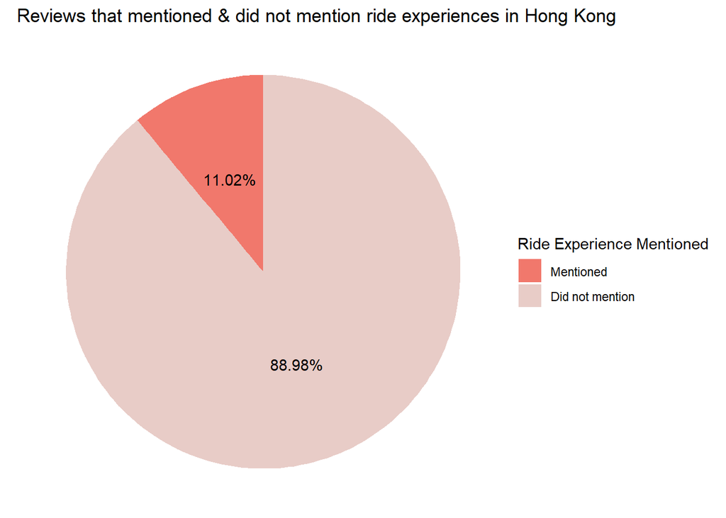

```r
p_mention_orno%>%
  ggplot(aes(x="", y=freq_branch_pct, fill=rides)) +
  geom_bar(stat="identity", width=1) +
  coord_polar("y", start=0) +
  labs(fill = "Ride Experience Mentioned") +
  ggtitle("Reviews that mentioned & did not mention ride experiences in Hong Kong") +
  theme_void()+
  geom_text(aes(label = paste0(freq_branch_pct, "%")), position = position_stack(vjust=0.5)) +
  scale_fill_manual(values=c("#F1786C", "#E8CCC7"),
                    labels=c("Mentioned", "Did not mention"))
```

88.98% did not mention ride experiences in HK branch with an average rating of 4.21; 11.02% mentioned ride experiences in HK branch with a slightly higher average rating of 4.26.

```r
# proportions of rides mentioned in the branch
# over total number of reviews in the branch & over reviews that mentioned rides in branch
p_rides <- freq_all[3:18, 1:5]

# filter freqs >= 2% of the reviews that mentioned rides in the branch, rating high to low
hot_rides <- p_rides %>%
  filter(freq_Mention_pct >= 2)
hot_rides
```

```
##             rides counts avg_rating freq_branch_pct freq_Mention_pct
## 1  Space_Mountain    785       4.26            8.58            77.88
## 2     Small_World    179       4.35            1.96            17.76
## 3 Haunted_Mansion     94       4.31            1.03             9.33
## 4   Jungle_Cruise     85       4.25            0.93             8.43
## 5         Pirates     29       3.76            0.32             2.88
## 6      Star_Tours     21       4.29            0.23             2.08
```

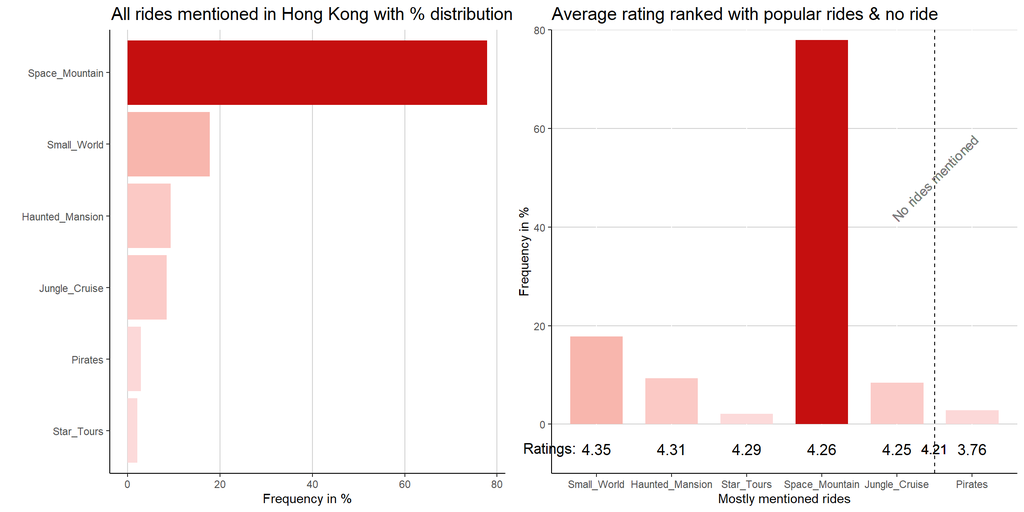

```r
#
ride_rank_plot <- hot_rides%>%
  ggplot(aes(x=reorder(rides,freq_Mention_pct),
             y=freq_Mention_pct, fill=freq_Mention_pct))+
  geom_col(position='dodge')+
  coord_flip()+
  labs(x = "", y = "Frequency in %") +
  ggtitle("All rides mentioned in Hong Kong with % distribution")+
  scale_fill_gradient(low = "#FCDADA", high = "#C50F0F", guide = FALSE) +
  theme(plot.background = element_blank(),
        panel.background = element_blank(),
        panel.grid.major.x  = element_line(color = "light grey"),
        axis.line = element_line(color = "black"),
        plot.title = element_text(size = 15, hjust = -0.267, vjust = 1))

# rating
rating_rank_plot <- hot_rides %>%
  ggplot() +
  geom_col(aes(x=reorder(rides, -avg_rating), y=freq_Mention_pct, fill=freq_Mention_pct),
           width=0.7, position='dodge')+
  scale_y_continuous(name = "Frequency in %",
                     expand = c(0,0),
                     limits = c(-10, 80)) +
  geom_text(aes(x=rides, y=-5, label=avg_rating), size = 4.5) +
  labs(x = "Mostly mentioned rides", y = "Frequency in %") +
  ggtitle("Average rating ranked with popular rides & no ride") +
  scale_fill_gradient(low = "#FCDADA", high = "#C50F0F", guide = FALSE)+
  labs(tag ="Ratings:")+
  theme(plot.background = element_blank(),
        panel.background = element_blank(),
        panel.grid.major.y  = element_line(color = "light grey"),
        axis.line = element_line(color = "black"),
        plot.tag.position = c(0.01,0.115),
        plot.tag = element_text(hjust = 0, size=12.5),
        plot.title = element_text(size = 15)) +
  geom_vline(xintercept = 5.5, linetype = "dashed") +
  geom_text(aes(label = "No rides mentioned", x = 5.5, y=50), angle = 45, color = "#7C7C7C", size = 4)+
  geom_text(aes(label = "4.21", x = 5.5, y=-5), size = 4)



grid.arrange(ride_rank_plot, rating_rank_plot, ncol = 2)
```

From the plot above, We can see that the mostly mentioned ride in Hong Kong branch is Space_Mountain ride, following by Small_World and Haunted_Mansion. Reviews who mentioned Small_World, Haunted_Mansion, and Star_Tours tend to give higher ratings on average. Space_Mountain, the ride that significantly more people mentioned about, obtained an average ratings that is only slightly higher than those that did not mention any rides. Pirates ride received lower rating than those did not mention rides, which might suggest that visitors might have bad impressions on this ride and caused them to leave a relatively neutral or negative ratings.

### CA

```r
head(cali)
```

```
## # A tibble: 6 × 25
##   Rating Branch    Ratin…¹ Astro…² Big_T…³ Dinos…⁴ Dumbo Exped…⁵ Haunt…⁶ Small…⁷
##    <dbl> <chr>     <chr>     <dbl>   <dbl>   <dbl> <dbl>   <dbl>   <dbl>   <dbl>
## 1      5 Disneyla… positi…       0       0       0     0       0       0       0
## 2      5 Disneyla… positi…       0       0       0     0       0       0       0
## 3      4 Disneyla… positi…       0       0       0     0       0       0       0
## 4      5 Disneyla… positi…       0       0       0     0       0       0       1
## 5      5 Disneyla… positi…       0       0       0     0       0       0       0
## 6      5 Disneyla… positi…       0       0       0     0       0       0       0
## # … with 15 more variables: Jungle_Cruise <dbl>, Mad_Tea <dbl>,
## #   Peter_Pan <dbl>, Pirates <dbl>, Soarin_Around <dbl>, Space_Mountain <dbl>,
## #   Splash_Mountain <dbl>, Star_Tours <dbl>, Test_Track <dbl>,
## #   Winnie_Pooh <dbl>, Twilight_Zone <dbl>, Toy_Story <dbl>, Under_Sea <dbl>,
## #   mention_ride <dbl>, no_mention_ride <dbl>, and abbreviated variable names
## #   ¹Rating_type, ²Astro_Orbiter, ³Big_Thunder, ⁴Dinosaur, ⁵Expedition_Everest,
## #   ⁶Haunted_Mansion, ⁷Small_World
```

```r
rides_ca = data.frame(rd=names(colSums(cali[c(4:25)])))
rides_ca   # CA: 1:3(info) + 4:23(20 rides) + 24:25(2 mention cols)
```

```
##                    rd
## 1       Astro_Orbiter
## 2         Big_Thunder
## 3            Dinosaur
## 4               Dumbo
## 5  Expedition_Everest
## 6     Haunted_Mansion
## 7         Small_World
## 8       Jungle_Cruise
## 9             Mad_Tea
## 10          Peter_Pan
## 11            Pirates
## 12      Soarin_Around
## 13     Space_Mountain
## 14    Splash_Mountain
## 15         Star_Tours
## 16         Test_Track
## 17        Winnie_Pooh
## 18      Twilight_Zone
## 19          Toy_Story
## 20          Under_Sea
## 21       mention_ride
## 22    no_mention_ride
```

```r
colSums(cali[c(4:25)])
```

```
##      Astro_Orbiter        Big_Thunder           Dinosaur              Dumbo
##                  8                 85                 27                  5
## Expedition_Everest    Haunted_Mansion        Small_World      Jungle_Cruise
##                  4                828                401                244
##            Mad_Tea          Peter_Pan            Pirates      Soarin_Around
##                 23                 48                663                  4
##     Space_Mountain    Splash_Mountain         Star_Tours         Test_Track
##               1439                840                548                 10
##        Winnie_Pooh      Twilight_Zone          Toy_Story          Under_Sea
##                  4                  7                 20                 15
##       mention_ride    no_mention_ride
##               3079              15123
```

```r
# get the avg rating for each ride
df <- data.frame()
for (i in 1:nrow(rides_ca)) {
  for (k in rides_ca[i,]) {
    avg_rating <- cali %>%
        filter(cali[,k] != 0) %>%
        summarise(avg_rating = mean(Rating))
    df <- rbind(df, avg_rating)
  }
}

# ride names, counts, and average ratings
ride_mention_count <- data.frame(rides = names(colSums(cali[c(4:25)])),
                                 counts = as.numeric(colSums(cali[c(4:25)])),
                                 avg_raing = df)

# Frequency of each ride in total branch reviews & in reviews that mentioned rides in the branch
freq_all <- ride_mention_count %>%
  mutate(freq_branch_pct = counts/nrow(cali)*100,
         freq_Mention_pct = counts/counts[21]*100) %>%
  mutate_at(c(3:5), round, digits = 2)%>%
  arrange(desc(freq_Mention_pct))
freq_all
```

```
##                 rides counts avg_rating freq_branch_pct freq_Mention_pct
## 1     no_mention_ride  15123       4.43           83.08           491.17
## 2        mention_ride   3079       4.36           16.92           100.00
## 3      Space_Mountain   1439       4.37            7.91            46.74
## 4     Splash_Mountain    840       4.38            4.61            27.28
## 5     Haunted_Mansion    828       4.43            4.55            26.89
## 6             Pirates    663       4.42            3.64            21.53
## 7          Star_Tours    548       4.52            3.01            17.80
## 8         Small_World    401       4.36            2.20            13.02
## 9       Jungle_Cruise    244       4.37            1.34             7.92
## 10        Big_Thunder     85       4.59            0.47             2.76
## 11          Peter_Pan     48       4.31            0.26             1.56
## 12           Dinosaur     27       4.37            0.15             0.88
## 13            Mad_Tea     23       4.78            0.13             0.75
## 14          Toy_Story     20       4.25            0.11             0.65
## 15          Under_Sea     15       4.40            0.08             0.49
## 16         Test_Track     10       4.30            0.05             0.32
## 17      Astro_Orbiter      8       4.62            0.04             0.26
## 18      Twilight_Zone      7       4.43            0.04             0.23
## 19              Dumbo      5       4.80            0.03             0.16
## 20 Expedition_Everest      4       4.50            0.02             0.13
## 21      Soarin_Around      4       4.50            0.02             0.13
## 22        Winnie_Pooh      4       5.00            0.02             0.13
```

```r
# proportions of reviews that mentioned rides & no mention rides in the branch
p_mention_orno <- freq_all[1:2, 1:4]
p_mention_orno
```

```
##             rides counts avg_rating freq_branch_pct
## 1 no_mention_ride  15123       4.43           83.08
## 2    mention_ride   3079       4.36           16.92
```

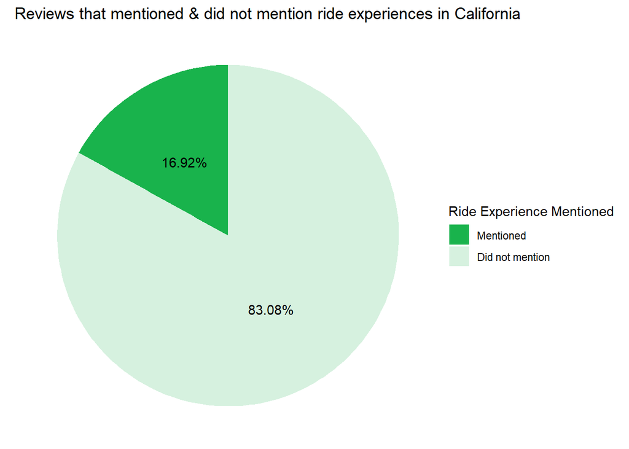

```r
p_mention_orno%>%
  ggplot(aes(x="", y=freq_branch_pct, fill=rides)) +
  geom_bar(stat="identity", width=1) +
  coord_polar("y", start=0) +
  labs(fill = "Ride Experience Mentioned") +
  ggtitle("Reviews that mentioned & did not mention ride experiences in California") +
  theme_void()+
  geom_text(aes(label = paste0(freq_branch_pct, "%")), position = position_stack(vjust=0.5)) +
  scale_fill_manual(values=c("#19B34C", "#D6F1DF"),
                    labels=c("Mentioned", "Did not mention"))
```

83.08% did not mention ride experiences in CA branch with an average rating of 4.43; 16.92% mentioned ride experiences in CA branch with a slightly lower average rating of 4.36. This finding is different from What we had in HK branch, where the average rating is slightly higher for reviews that mentioned raide experiences.

```r
# proportions of rides mentioned in the branch
# over total number of reviews in the branch & over reviews that mentioned rides in branch
p_rides <- freq_all[3:22, 1:5]

# filter freqs >= 2% of the reviews that mentioned rides in the branch, rating high to low
hot_rides <- p_rides %>%
  filter(freq_Mention_pct >= 2)
hot_rides
```

```
##             rides counts avg_rating freq_branch_pct freq_Mention_pct
## 1  Space_Mountain   1439       4.37            7.91            46.74
## 2 Splash_Mountain    840       4.38            4.61            27.28
## 3 Haunted_Mansion    828       4.43            4.55            26.89
## 4         Pirates    663       4.42            3.64            21.53
## 5      Star_Tours    548       4.52            3.01            17.80
## 6     Small_World    401       4.36            2.20            13.02
## 7   Jungle_Cruise    244       4.37            1.34             7.92
## 8     Big_Thunder     85       4.59            0.47             2.76
```

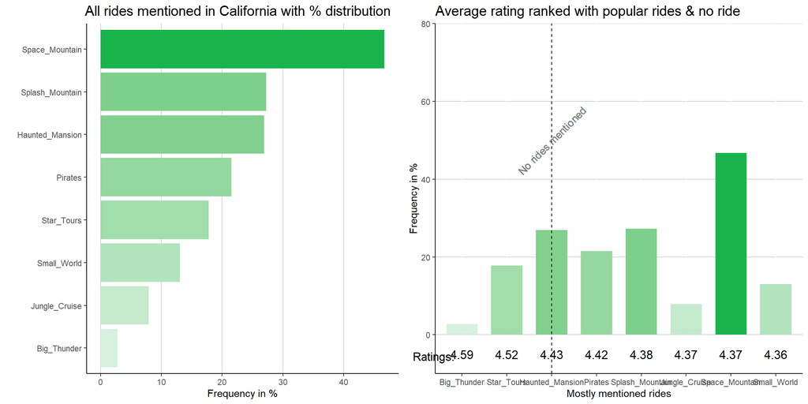

```r
#
ride_rank_plot <- hot_rides%>%
  ggplot(aes(x=reorder(rides,freq_Mention_pct),
             y=freq_Mention_pct, fill=freq_Mention_pct))+
  geom_col(position='dodge')+
  coord_flip()+
  labs(x = "", y = "Frequency in %") +
  ggtitle("All rides mentioned in California with % distribution")+
  scale_fill_gradient(low = "#D6F1DF", high = "#19B34C", guide = FALSE) +
  theme(plot.background = element_blank(),
        panel.background = element_blank(),
        panel.grid.major.x  = element_line(color = "light grey"),
        axis.line = element_line(color = "black"),
        plot.title = element_text(size = 15, hjust = -0.267, vjust = 1))

#
rating_rank_plot <- hot_rides %>%
  ggplot() +
  geom_col(aes(x=reorder(rides, -avg_rating), y=freq_Mention_pct, fill=freq_Mention_pct),
           width=0.7, position='dodge')+
  scale_y_continuous(name = "Frequency in %",
                     expand = c(0,0),
                     limits = c(-10, 80)) +
  geom_text(aes(x=rides, y=-5, label=avg_rating), size = 4.5) +
  labs(x = "Mostly mentioned rides", y = "Frequency in %") +
  ggtitle("Average rating ranked with popular rides & no ride") +
  scale_fill_gradient(low = "#D6F1DF", high = "#19B34C", guide = FALSE)+
  labs(tag ="Ratings:")+
  theme(plot.background = element_blank(),
        panel.background = element_blank(),
        panel.grid.major.y  = element_line(color = "light grey"),
        axis.line = element_line(color = "black"),
        plot.tag.position = c(0.01,0.108),
        plot.tag = element_text(hjust = 0, size=12.5),
        plot.title = element_text(size = 15)) +
  geom_vline(xintercept = 3, linetype = "dashed") +
  geom_text(aes(label = "No rides mentioned", x = 3, y=50), angle = 45, color = "#7C7C7C", size = 4)+
  geom_text(aes(label = " ", x = 5.5, y=-5), size = 5)



grid.arrange(ride_rank_plot, rating_rank_plot, ncol = 2)
```

From the plot above, We can see that the mostly mentioned ride in California branch is also Space_Mountain ride, which is the same as in Hong Kong branch, following by Splash_Mountain and Haunted_Mansion. However, when it comes to average ratings, we found that in California, rides that people tend to mention more about did not lead to higher ratings. The rating even tend to be lower than those did not mention any rides. The mostly mentioned ride, Space_Mountain, received an average rating of 4.37. Although this average rating is slightly higher than the same ride in Hong Kong branch, it is even lower than the ratings that did not mention rides in California. This might suggest that consumers are not entirely happy about their general ride experiences.

### PR

```r
head(paris)
```

```
## # A tibble: 6 × 22
##   Rating Branch    Ratin…¹ Astro…² Big_T…³ Dinos…⁴ Dumbo Haunt…⁵ Small…⁶ Jungl…⁷
##    <dbl> <chr>     <chr>     <dbl>   <dbl>   <dbl> <dbl>   <dbl>   <dbl>   <dbl>
## 1      5 Disneyla… positi…       0       0       0     0       0       0       0
## 2      4 Disneyla… positi…       0       0       0     0       0       0       0
## 3      5 Disneyla… positi…       0       0       0     0       1       0       0
## 4      4 Disneyla… positi…       0       0       0     0       0       0       0
## 5      5 Disneyla… positi…       0       0       0     0       0       0       0
## 6      5 Disneyla… positi…       0       0       0     0       0       0       0
## # … with 12 more variables: Mission_Space <dbl>, Peter_Pan <dbl>,
## #   Pirates <dbl>, Rock_Roller <dbl>, Space_Mountain <dbl>,
## #   Splash_Mountain <dbl>, Star_Tours <dbl>, Twilight_Zone <dbl>,
## #   Toy_Story <dbl>, Under_Sea <dbl>, mention_ride <dbl>,
## #   no_mention_ride <dbl>, and abbreviated variable names ¹Rating_type,
## #   ²Astro_Orbiter, ³Big_Thunder, ⁴Dinosaur, ⁵Haunted_Mansion, ⁶Small_World,
## #   ⁷Jungle_Cruise
```

```r
rides_pr = data.frame(rd=names(colSums(paris[c(4:22)])))
rides_pr    # PR: 4:20(17 rides) + 21:22(2 mention cols)
```

```
##                 rd
## 1    Astro_Orbiter
## 2      Big_Thunder
## 3         Dinosaur
## 4            Dumbo
## 5  Haunted_Mansion
## 6      Small_World
## 7    Jungle_Cruise
## 8    Mission_Space
## 9        Peter_Pan
## 10         Pirates
## 11     Rock_Roller
## 12  Space_Mountain
## 13 Splash_Mountain
## 14      Star_Tours
## 15   Twilight_Zone
## 16       Toy_Story
## 17       Under_Sea
## 18    mention_ride
## 19 no_mention_ride
```

```r
colSums(paris[c(4:22)])
```

```
##   Astro_Orbiter     Big_Thunder        Dinosaur           Dumbo Haunted_Mansion
##               1              27               1              17             141
##     Small_World   Jungle_Cruise   Mission_Space       Peter_Pan         Pirates
##             286               8               5              78             601
##     Rock_Roller  Space_Mountain Splash_Mountain      Star_Tours   Twilight_Zone
##               5            1241              20             334              16
##       Toy_Story       Under_Sea    mention_ride no_mention_ride
##               1               2            1951           10743
```

```r
# get the avg rating for each ride
df <- data.frame()
for (i in 1:nrow(rides_pr)) {
  for (k in rides_pr[i,]) {
    avg_rating <- paris %>%
        filter(paris[,k] != 0) %>%
        summarise(avg_rating = mean(Rating))
    df <- rbind(df, avg_rating)
  }
}

# ride names, counts, and average ratings
ride_mention_count <- data.frame(rides = names(colSums(paris[c(4:22)])),
                                 counts = as.numeric(colSums(paris[c(4:22)])),
                                 avg_raing = df)

# Frequency of each ride in total branch reviews & in reviews that mentioned rides in the branch
freq_all <- ride_mention_count %>%
  mutate(freq_branch_pct = counts/nrow(paris)*100,
         freq_Mention_pct = counts/counts[18]*100) %>%
  mutate_at(c(3:5), round, digits = 2)%>%
  arrange(desc(freq_Mention_pct))
freq_all
```

```
##              rides counts avg_rating freq_branch_pct freq_Mention_pct
## 1  no_mention_ride  10743       3.98           84.63           550.64
## 2     mention_ride   1951       3.97           15.37           100.00
## 3   Space_Mountain   1241       4.01            9.78            63.61
## 4          Pirates    601       3.96            4.73            30.80
## 5       Star_Tours    334       3.96            2.63            17.12
## 6      Small_World    286       4.17            2.25            14.66
## 7  Haunted_Mansion    141       3.73            1.11             7.23
## 8        Peter_Pan     78       4.18            0.61             4.00
## 9      Big_Thunder     27       3.89            0.21             1.38
## 10 Splash_Mountain     20       3.95            0.16             1.03
## 11           Dumbo     17       4.18            0.13             0.87
## 12   Twilight_Zone     16       3.88            0.13             0.82
## 13   Jungle_Cruise      8       3.88            0.06             0.41
## 14   Mission_Space      5       4.20            0.04             0.26
## 15     Rock_Roller      5       3.40            0.04             0.26
## 16       Under_Sea      2       5.00            0.02             0.10
## 17   Astro_Orbiter      1       4.00            0.01             0.05
## 18        Dinosaur      1       3.00            0.01             0.05
## 19       Toy_Story      1       5.00            0.01             0.05
```

```r
# proportions of reviews that mentioned rides & no mention rides in the branch
p_mention_orno <- freq_all[1:2, 1:4]
p_mention_orno
```

```
##             rides counts avg_rating freq_branch_pct
## 1 no_mention_ride  10743       3.98           84.63
## 2    mention_ride   1951       3.97           15.37
```

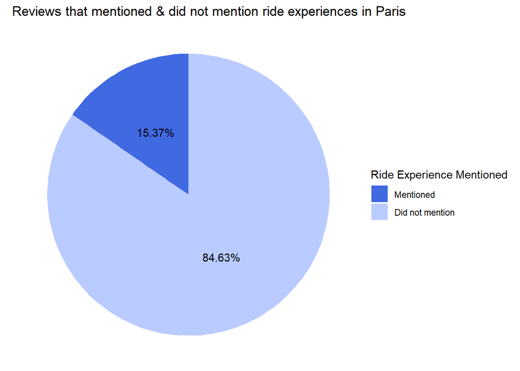

```r
#                 avg_rating  frequency %
# HK: no_mention:   4.21        88.98
#     mentioned:    4.26        11.02
# CA: no_mention:   4.43        83.08
#     mentioned:    4.36        16.92


p_mention_orno%>%
  ggplot(aes(x="", y=freq_branch_pct, fill=rides)) +
  geom_bar(stat="identity", width=1) +
  coord_polar("y", start=0) +
  labs(fill = "Ride Experience Mentioned") +
  ggtitle("Reviews that mentioned & did not mention ride experiences in Paris") +
  theme_void()+
  geom_text(aes(label = paste0(freq_branch_pct, "%")), position = position_stack(vjust=0.5)) +
  scale_fill_manual(values=c("#4169E2", "#BACBFF"),
                    labels=c("Mentioned", "Did not mention"))
```

84.63% did not mention ride experiences in PR branch with an average rating of 3.98; 15.37% mentioned ride experiences in PR branch with a very similar average rating of 3.97. Comparing to the two branches before, the two average ratings are much lower than in HK and CA. This might suggest that Paris branch receive generally lower ratings compared to other branches. The proportions of rides mentioned in the review text verses did not are similar compared to other two branches.

```r
# proportions of rides mentioned in the branch
# over total number of reviews in the branch & over reviews that mentioned rides in branch
p_rides <- freq_all[3:19, 1:5]

# filter freqs >= 2% of the reviews that mentioned rides in the branch, rating high to low
hot_rides <- p_rides %>%
  filter(freq_Mention_pct >= 2)
hot_rides
```

```
##             rides counts avg_rating freq_branch_pct freq_Mention_pct
## 1  Space_Mountain   1241       4.01            9.78            63.61
## 2         Pirates    601       3.96            4.73            30.80
## 3      Star_Tours    334       3.96            2.63            17.12
## 4     Small_World    286       4.17            2.25            14.66
## 5 Haunted_Mansion    141       3.73            1.11             7.23
## 6       Peter_Pan     78       4.18            0.61             4.00
```

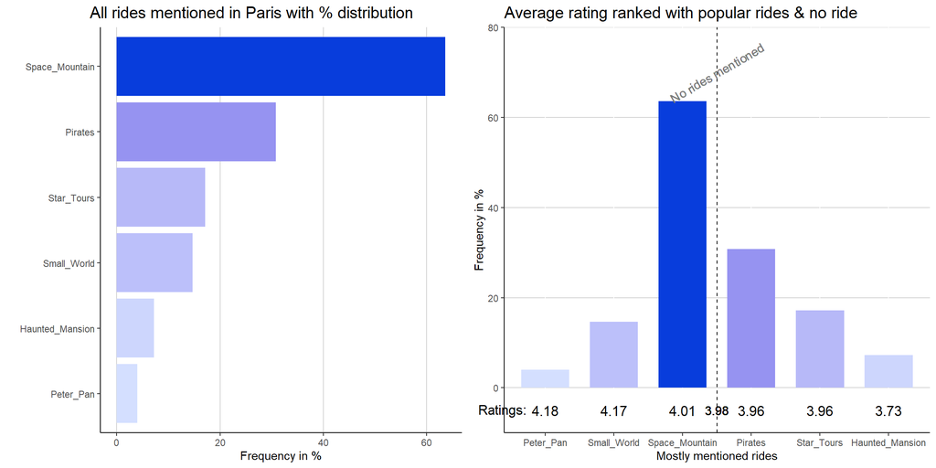

```r
#
ride_rank_plot <- hot_rides%>%
  ggplot(aes(x=reorder(rides,freq_Mention_pct),
             y=freq_Mention_pct, fill=freq_Mention_pct))+
  geom_col(position='dodge')+
  coord_flip()+
  labs(x = "", y = "Frequency in %") +
  ggtitle("All rides mentioned in Paris with % distribution")+
  scale_fill_gradient(low = "#D4DFFF", high = "#083DDC", guide = FALSE) +
  theme(plot.background = element_blank(),
        panel.background = element_blank(),
        panel.grid.major.x  = element_line(color = "light grey"),
        axis.line = element_line(color = "black"),
        plot.title = element_text(size = 15, hjust = -0.267, vjust = 1))

#
rating_rank_plot <- hot_rides %>%
  ggplot() +
  geom_col(aes(x=reorder(rides, -avg_rating), y=freq_Mention_pct, fill=freq_Mention_pct),
           width=0.7, position='dodge')+
  scale_y_continuous(name = "Frequency in %",
                     expand = c(0,0),
                     limits = c(-10, 80)) +
  geom_text(aes(x=rides, y=-5, label=avg_rating), size = 4.5) +
  labs(x = "Mostly mentioned rides", y = "Frequency in %") +
  ggtitle("Average rating ranked with popular rides & no ride") +
  scale_fill_gradient(low = "#D4DFFF", high = "#083DDC", guide = FALSE)+
  labs(tag ="Ratings:")+
  theme(plot.background = element_blank(),
        panel.background = element_blank(),
        panel.grid.major.y  = element_line(color = "light grey"),
        axis.line = element_line(color = "black"),
        plot.tag.position = c(0.01,0.115),
        plot.tag = element_text(hjust = 0, size=12.5),
        plot.title = element_text(size = 15)) +
  geom_vline(xintercept = 3.5, linetype = "dashed") +
  geom_text(aes(label = "No rides mentioned", x = 3.5, y=70), angle = 30, color = "#7C7C7C", size = 4)+
  geom_text(aes(label = "3.98", x = 3.5, y=-5), size = 4)

grid.arrange(ride_rank_plot, rating_rank_plot, ncol = 2)
```

The mostly mentioned ride in Paris branch is also Space_Mountain ride, following by Pirates and Star_Tours. As mentioned before, the general rating for Paris branch is much lower than other two branches. This is also true for the reviews regardless of mentioning or not mentioning ride experiences. Peter_Pan and Small_World received similarly higher average ratings, following by Space_Mountain. Reviewers who did not mention any ride rated slightly higher on average than other rides including Pirates, Star_Tours, and Haunted Mansion. This might suggest that apart from Peter_Pan and Small_World, rides that are most frequently mentioned in Paris branch might tend to receive more neutral ratings. People tend not to give higher ratings when they mention rides that are popular or mostly mentioned compared with the ratings without mentioning rides, in which case, these most mentioned rides tend not to be more favorable among visitors.

## Sentiment Analysis

### Hong Kong

```r
afinn = get_sentiments('afinn')
```

Integrate the three branches and attach to original dataset

```r
# rbind all 3 branches
tri_branch <- rbind(hongkong[,20:21], cali[,24:25], paris[,21:22])
# cbind indicators to original dataset
disneyland <- cbind(disneyland, tri_branch)
```

Distribution of sentiment scores with ride experience

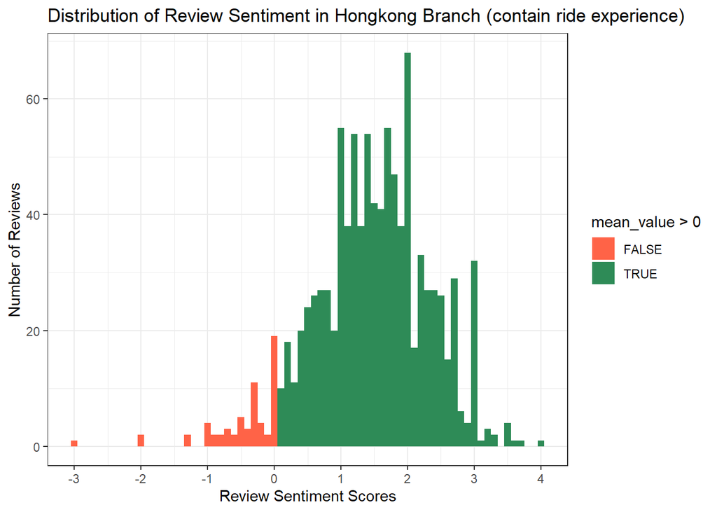

```r
dis_w_shop <- disneyland %>%
  filter(Branch == 'Disneyland_HongKong', mention_ride == 1) %>%
  select(Review_ID,Review_Text)%>%
  group_by(Review_ID)%>%
  unnest_tokens(output=word,input=Review_Text)%>%
  inner_join(afinn)

agg_data <- aggregate(dis_w_shop[, 'value'], by = list(dis_w_shop$Review_ID), FUN = function(x) mean(x))

colnames(agg_data) <- c("Review_ID", "mean_value")
agg_data %>%
  ggplot(aes(x=mean_value,fill=mean_value>0))+
  geom_histogram(binwidth = 0.1)+
  scale_x_continuous(breaks=seq(-5,5,1))+
  scale_fill_manual(values=c('tomato','seagreen'))+
  theme_bw() +
  labs(x = "Review Sentiment Scores", y = "Number of Reviews") +
  ggtitle("Distribution of Review Sentiment in Hongkong Branch (contain ride experience)")
```

Distribution of sentiment scores without ride experience

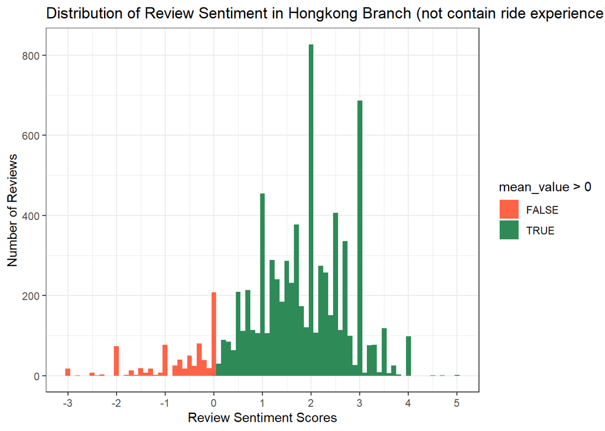

```r
dis_wt_shop <- disneyland %>%
  filter(Branch == 'Disneyland_HongKong', mention_ride == 0) %>%
  select(Review_ID,Review_Text)%>%
  group_by(Review_ID)%>%
  unnest_tokens(output=word,input=Review_Text)%>%
  inner_join(afinn)
agg_data <- aggregate(dis_wt_shop[, 'value'], by = list(dis_wt_shop$Review_ID), FUN = function(x) mean(x))

colnames(agg_data) <- c("Review_ID", "mean_value")
agg_data %>%
  ggplot(aes(x=mean_value,fill=mean_value>0))+
  geom_histogram(binwidth = 0.1)+
  scale_x_continuous(breaks=seq(-5,5,1))+
  scale_fill_manual(values=c('tomato','seagreen'))+
  theme_bw() +
  labs(x = "Review Sentiment Scores", y = "Number of Reviews") +
  ggtitle("Distribution of Review Sentiment in Hongkong Branch (not contain ride experience)")
```

### California

Distribution of sentiment scores with ride experience

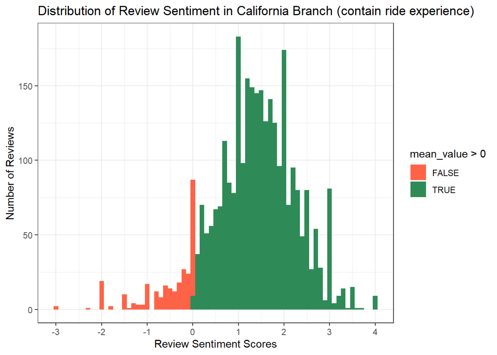

```r
dis_w_shop <- disneyland %>%
  filter(Branch == 'Disneyland_California', mention_ride == 1) %>%
  select(Review_ID,Review_Text)%>%
  group_by(Review_ID)%>%
  unnest_tokens(output=word,input=Review_Text)%>%
  inner_join(afinn)

agg_data <- aggregate(dis_w_shop[, 'value'], by = list(dis_w_shop$Review_ID), FUN = function(x) mean(x))

colnames(agg_data) <- c("Review_ID", "mean_value")
agg_data %>%
  ggplot(aes(x=mean_value,fill=mean_value>0))+
  geom_histogram(binwidth = 0.1)+
  scale_x_continuous(breaks=seq(-5,5,1))+
  scale_fill_manual(values=c('tomato','seagreen'))+
  theme_bw() +
  labs(x = "Review Sentiment Scores", y = "Number of Reviews") +
  ggtitle("Distribution of Review Sentiment in California Branch (contain ride experience)")
```

Distribution of sentiment scores without ride experience

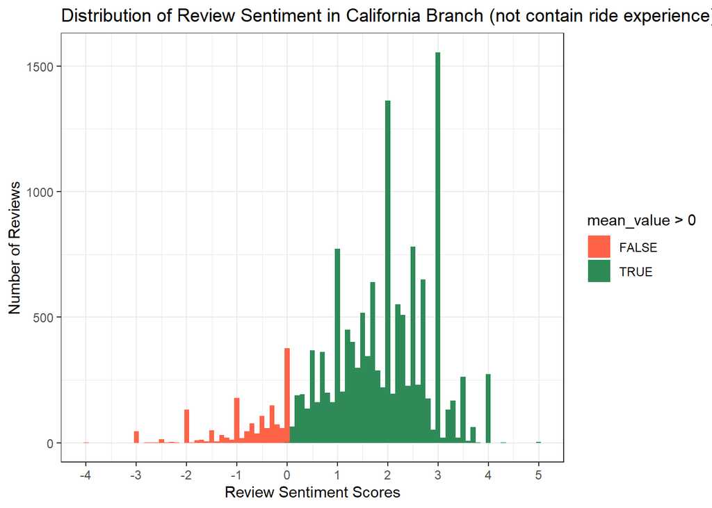

```r
dis_wt_shop <- disneyland %>%
  filter(Branch == 'Disneyland_California', mention_ride == 0) %>%
  select(Review_ID,Review_Text)%>%
  group_by(Review_ID)%>%
  unnest_tokens(output=word,input=Review_Text)%>%
  inner_join(afinn)
agg_data <- aggregate(dis_wt_shop[, 'value'], by = list(dis_wt_shop$Review_ID), FUN = function(x) mean(x))

colnames(agg_data) <- c("Review_ID", "mean_value")
agg_data %>%
  ggplot(aes(x=mean_value,fill=mean_value>0))+
  geom_histogram(binwidth = 0.1)+
  scale_x_continuous(breaks=seq(-5,5,1))+
  scale_fill_manual(values=c('tomato','seagreen'))+
  theme_bw() +
  labs(x = "Review Sentiment Scores", y = "Number of Reviews") +
  ggtitle("Distribution of Review Sentiment in California Branch (not contain ride experience)")
```

### Paris

Distribution of sentiment scores with ride experience

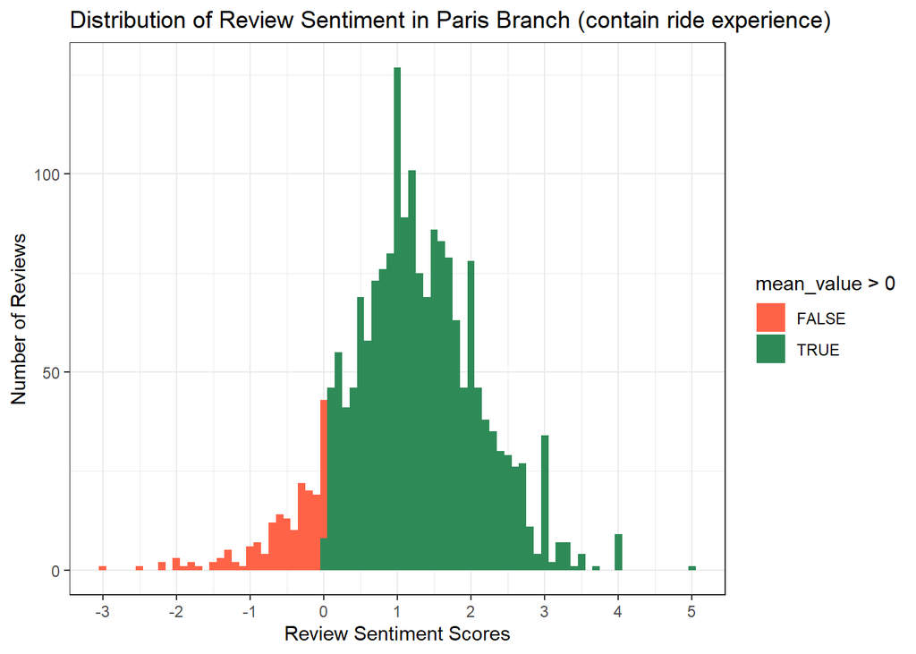

```r
dis_w_shop <- disneyland %>%
  filter(Branch == 'Disneyland_Paris', mention_ride == 1) %>%
  select(Review_ID,Review_Text)%>%
  group_by(Review_ID)%>%
  unnest_tokens(output=word,input=Review_Text)%>%
  inner_join(afinn)

agg_data <- aggregate(dis_w_shop[, 'value'], by = list(dis_w_shop$Review_ID), FUN = function(x) mean(x))

colnames(agg_data) <- c("Review_ID", "mean_value")
agg_data %>%
  ggplot(aes(x=mean_value,fill=mean_value>0))+
  geom_histogram(binwidth = 0.1)+
  scale_x_continuous(breaks=seq(-5,5,1))+
  scale_fill_manual(values=c('tomato','seagreen'))+
  theme_bw() +
  labs(x = "Review Sentiment Scores", y = "Number of Reviews") +
  ggtitle("Distribution of Review Sentiment in Paris Branch (contain ride experience)")
```

Distribution of sentiment scores without ride experience

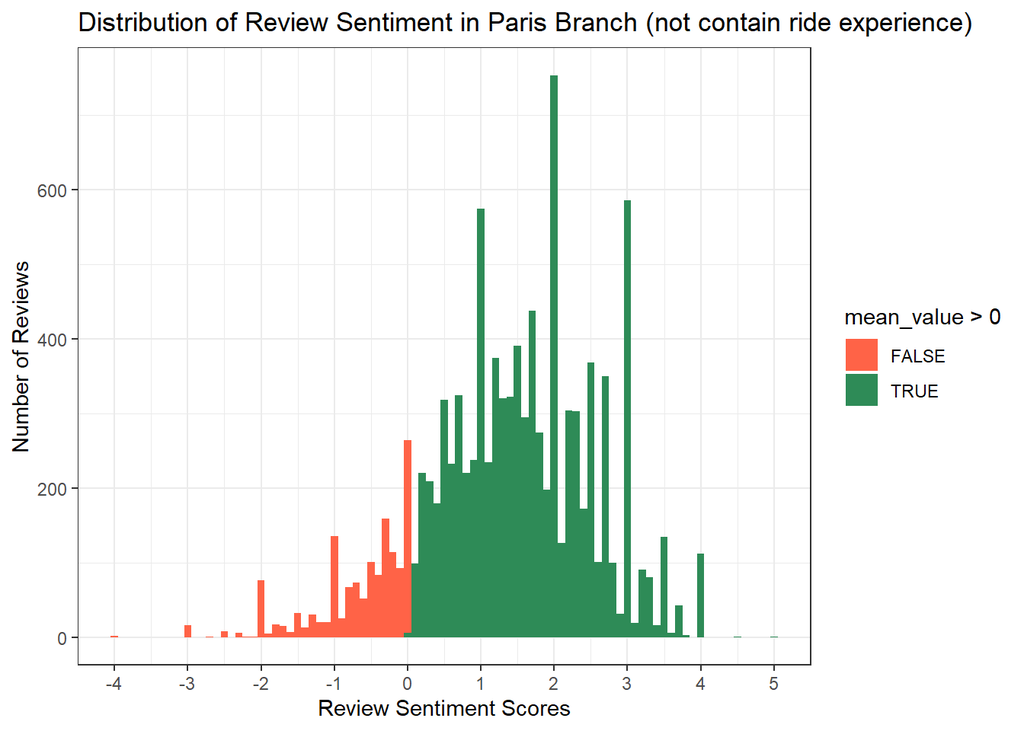

```r
dis_wt_shop <- disneyland %>%
  filter(Branch == 'Disneyland_Paris', mention_ride == 0) %>%
  select(Review_ID,Review_Text)%>%
  group_by(Review_ID)%>%
  unnest_tokens(output=word,input=Review_Text)%>%
  inner_join(afinn)
agg_data <- aggregate(dis_wt_shop[, 'value'], by = list(dis_wt_shop$Review_ID), FUN = function(x) mean(x))

colnames(agg_data) <- c("Review_ID", "mean_value")
agg_data %>%
  ggplot(aes(x=mean_value,fill=mean_value>0))+
  geom_histogram(binwidth = 0.1)+
  scale_x_continuous(breaks=seq(-5,5,1))+
  scale_fill_manual(values=c('tomato','seagreen'))+
  theme_bw() +
  labs(x = "Review Sentiment Scores", y = "Number of Reviews") +
  ggtitle("Distribution of Review Sentiment in Paris Branch (not contain ride experience)")
```

## Overall Sentiment Analytis

Calculate proportions and average scores required

```r
##### hong kong#####
# proportion of positive sentiment with shopping words
pos_prop_w_shop_hk <- disneyland %>%
  filter(Branch == 'Disneyland_HongKong', mention_ride == 1) %>%
  select(Review_ID, Review_Text) %>%
  unnest_tokens(output = word, input = Review_Text) %>%
  inner_join(afinn) %>%
  mutate(positive = ifelse(value >= 0, 1, 0)) %>%
  summarize(proportion_positive = sum(positive) / NROW(word))

#  proportion of positive sentiment without shopping words
pos_prop_wt_shop_hk <- disneyland %>%
  filter(Branch == 'Disneyland_HongKong', mention_ride == 0) %>%
  select(Review_ID, Review_Text) %>%
  unnest_tokens(output = word, input = Review_Text) %>%
  inner_join(afinn) %>%
  mutate(positive = ifelse(value >= 0, 1, 0)) %>%
  summarize(proportion_positive = sum(positive) / NROW(word))


# average sentiment score with shopping words
mean_w_shop_hk <- disneyland %>%
  filter(Branch == 'Disneyland_HongKong', mention_ride == 1) %>%
  select(Review_ID,Review_Text)%>%
  group_by(Review_ID)%>%
  unnest_tokens(output=word,input=Review_Text)%>%
  inner_join(afinn) %>%
  ungroup() %>%
  summarize(avg = mean(value))

# average sentiment score without shopping words
mean_wt_shop_hk <- disneyland %>%
  filter(Branch == 'Disneyland_HongKong', mention_ride == 0) %>%
  select(Review_ID,Review_Text)%>%
  group_by(Review_ID)%>%
  unnest_tokens(output=word,input=Review_Text)%>%
  inner_join(afinn) %>%
  ungroup() %>%
  summarize(avg = mean(value))


##### california #####
# proportion of positive sentiment with shopping words
pos_prop_w_shop_ca <- disneyland %>%
  filter(Branch == 'Disneyland_California', mention_ride == 1) %>%
  select(Review_ID, Review_Text) %>%
  unnest_tokens(output = word, input = Review_Text) %>%
  inner_join(afinn) %>%
  mutate(positive = ifelse(value >= 0, 1, 0)) %>%
  summarize(proportion_positive = sum(positive) / NROW(word))

#  proportion of positive sentiment without shopping words
pos_prop_wt_shop_ca <- disneyland %>%
  filter(Branch == 'Disneyland_California', mention_ride == 0) %>%
  select(Review_ID, Review_Text) %>%
  unnest_tokens(output = word, input = Review_Text) %>%
  inner_join(afinn) %>%
  mutate(positive = ifelse(value >= 0, 1, 0)) %>%
  summarize(proportion_positive = sum(positive) / NROW(word))

# average sentiment score with shopping words
mean_w_shop_ca <- disneyland %>%
  filter(Branch == 'Disneyland_California', mention_ride == 1) %>%
  select(Review_ID,Review_Text)%>%
  group_by(Review_ID)%>%
  unnest_tokens(output=word,input=Review_Text)%>%
  inner_join(afinn) %>%
  ungroup() %>%
  summarize(avg = mean(value))

# average sentiment score without shopping words
mean_wt_shop_ca <- disneyland %>%
  filter(Branch == 'Disneyland_California', mention_ride == 0) %>%
  select(Review_ID,Review_Text)%>%
  group_by(Review_ID)%>%
  unnest_tokens(output=word,input=Review_Text)%>%
  inner_join(afinn) %>%
  ungroup() %>%
  summarize(avg = mean(value))



##### paris #####
# proportion of positive sentiment with shopping words
pos_prop_w_shop_paris <- disneyland %>%
  filter(Branch == 'Disneyland_Paris', mention_ride == 1) %>%
  select(Review_ID, Review_Text) %>%
  unnest_tokens(output = word, input = Review_Text) %>%
  inner_join(afinn) %>%
  mutate(positive = ifelse(value >= 0, 1, 0)) %>%
  summarize(proportion_positive = sum(positive) / NROW(word))

#  proportion of positive sentiment without shopping words
pos_prop_wt_shop_paris <- disneyland %>%
  filter(Branch == 'Disneyland_Paris', mention_ride == 0) %>%
  select(Review_ID, Review_Text) %>%
  unnest_tokens(output = word, input = Review_Text) %>%
  inner_join(afinn) %>%
  mutate(positive = ifelse(value >= 0, 1, 0)) %>%
  summarize(proportion_positive = sum(positive) / NROW(word))

# average sentiment score with shopping words
mean_w_shop_paris <- disneyland %>%
  filter(Branch == 'Disneyland_Paris', mention_ride == 1) %>%
  select(Review_ID,Review_Text)%>%
  group_by(Review_ID)%>%
  unnest_tokens(output=word,input=Review_Text)%>%
  inner_join(afinn) %>%
  ungroup() %>%
  summarize(avg = mean(value))

# average sentiment score without shopping words
mean_wt_shop_paris <- disneyland %>%
  filter(Branch == 'Disneyland_Paris', mention_ride == 0) %>%
  select(Review_ID,Review_Text)%>%
  group_by(Review_ID)%>%
  unnest_tokens(output=word,input=Review_Text)%>%
  inner_join(afinn) %>%
  ungroup() %>%
  summarize(avg = mean(value))
```

Proportion of positive words in reviews w/wt shopping words

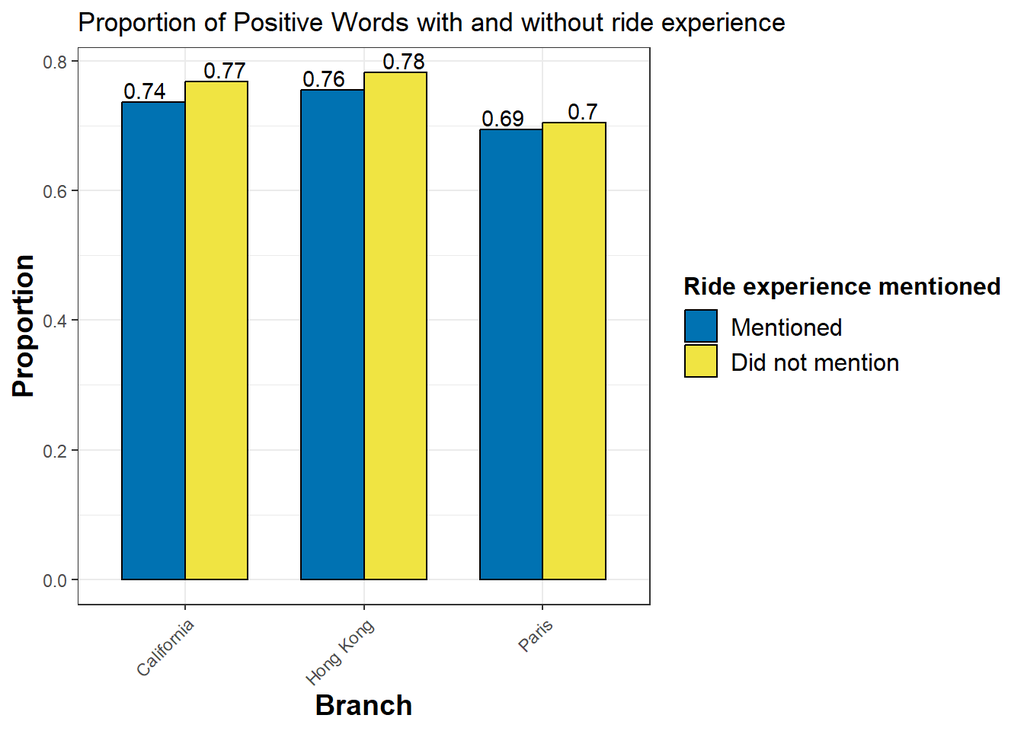

```r
# make proportion plot
df_prop = data.frame(branch = c('Hong Kong', 'California', 'Paris'),
                     prop_pos_words_w_shop = c(as.numeric(pos_prop_w_shop_hk), as.numeric(pos_prop_w_shop_ca), as.numeric(pos_prop_w_shop_paris)),
                     prop_pos_words_wt_shop = c(as.numeric(pos_prop_wt_shop_hk), as.numeric(pos_prop_wt_shop_ca), as.numeric(pos_prop_wt_shop_paris)))
df_prop_long <- tidyr::pivot_longer(df_prop, cols = c("prop_pos_words_w_shop", "prop_pos_words_wt_shop"), names_to = "category", values_to = "proportion")
ggplot(df_prop_long, aes(x = branch, y = proportion, fill = category)) +
  geom_bar(stat = "identity", position = "dodge", width = 0.7, color = "black", size = 0.5) +
  scale_fill_manual(values = c("#0072B2", "#F0E442"),
                    labels=c("Mentioned", "Did not mention")) +
  labs(title = "Proportion of Positive Words with and without ride experience", x = "Branch", y = "Proportion", fill = 'Ride experience mentioned') +
  geom_text(aes(label=round(proportion, 2)), position=position_dodge(width=0.9), vjust=-0.25) +
theme_bw() +
  theme(axis.text.x = element_text(angle = 45, hjust = 1),
        axis.title = element_text(size = 14, face = "bold"),
        legend.title = element_text(size = 12, face = "bold"),
        legend.text = element_text(size = 12))
```

Average sentiment scores of reviews w/wt shopping words

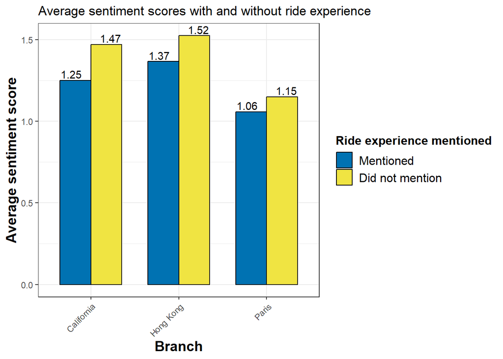

```r
# make average score plot
df_mean = data.frame(branch = c('Hong Kong', 'California', 'Paris'),
                     mean_w_shop = c(as.numeric(mean_w_shop_hk), as.numeric(mean_w_shop_ca), as.numeric(mean_w_shop_paris)),
                     mean_wt_shop = c(as.numeric(mean_wt_shop_hk), as.numeric(mean_wt_shop_ca), as.numeric(mean_wt_shop_paris)))
df_mean_long <- tidyr::pivot_longer(df_mean, cols = c("mean_w_shop", "mean_wt_shop"), names_to = "category", values_to = "proportion")
ggplot(df_mean_long, aes(x = branch, y = proportion, fill = category)) +
  geom_bar(stat = "identity", position = "dodge", width = 0.7, color = "black", size = 0.5) +
  scale_fill_manual(values = c("#0072B2", "#F0E442"),
                    labels=c("Mentioned", "Did not mention")) +
  labs(title = "Average sentiment scores with and without ride experience", x = "Branch", y = "Average sentiment score", fill = 'Ride experience mentioned') +
  geom_text(aes(label=round(proportion, 2)), position=position_dodge(width=0.9), vjust=-0.25) +
theme_bw() +
  theme(axis.text.x = element_text(angle = 45, hjust = 1),
        axis.title = element_text(size = 14, face = "bold"),
        legend.title = element_text(size = 12, face = "bold"),
        legend.text = element_text(size = 12))
```

### Discussions

Hypo 1: By cleaning and tokenizing the review texts, we converted the texts to lower cases, removed urls, punctuations, stopwords, and white spaces, created dictionaries to complete the words back later, and removed sparse terms. Then, getting the most frequently mentioned words in the reviews by calculating and ranking the occurrence frequencies, we were able to discover topics that reviewers tend to mention and thus tend to care about in the three branches. Focusing on the shopping experiences and ride experiences related topics, we were able to discover consumer demands in these two aspects. We have further utilized ratings data and conducted sentiment analysis using afinn sentiment scores on these two general topics to discover consumer preferences and qualify their experiences and sentiments.  
We have noticed that for all three branches, the same mostly mentioned words are “kid”, “park”, “ride”, and “wait”. Reviewer that commented Hong Kong branch seemed to mention topics that are more general topics, like the park itself, food, parade, queue, and fireworks. For California branch, people seemed to have more to say about queue experiences, waiting time, about the visiting crowd or visitor amount, and probably the speed and efficiency taking rides during their visits. Reviewer’s in Paris, however, seemed especially have more to say about their treatments and character meeting experiences.

### Recommendation:

Shopping related recommendations: In rating analysis, reviews of the Hong Kong branch mentions products such as toy, book and souvenir the most, and these words all received higher rating, while other products like bag and hat received relatively lower rating, which could be a direction for improvement. Reviews of the California branch mentions book, bag and souvenir the most, but these all received lower ratings, which might indicate that these products received more complaints and need to be improved. Reviews of the Paris branch focus much more on book, and bag are the secondly most frequent word. Overall, “book”, “toy” and “bag” are more commonly mentioned in all reviews. However, while “book” could have other meanings like booking an hotel, “toy” and “bag” should be the products that Disneyland should focus more on. An interesting point is that, even though the California branch received the least reviews about shopping, its ratings related to shopping’s relatively higher, so the California branch can advertise on the the shopping segment to earn more attention. On the other hand, Paris received the most shopping reviews, but its average rating on shopping words are much lower. The Paris branch could try to improve its shopping experience given the spotlight. In sentiment analysis, we observed that all three branches had lower proportion of positive words and lower average sentiment scores for reviews that are related to shopping. This fact partially indicates that there are more people complaining when they talk about shopping. Thus, all branches should put more emphasis on improving the shopping segment.

### Limitation:

We have only selected two major topics, shopping and ride experiences, to do investigations in this study. Other topics like kids and children experiences, interactions with characters, and fireworks, etc. These might also become important factors and topics that visitors care about and thus to give ratings.

### Future Study:

Future study could consider selecting more topics and to investigate the impact that may have on visitor ratings. For example, kids and children experiences, interactions with characters, and fireworks, etc.